# Coursera Class: Reproducible Research Week4 - Peer Review Assignment

April L

January 20, 2018

## Synopsis

Storms and other severe weather events can cause both public health and economic problems for communities and munipalitie.

This project involves exploring the US National Oceanic and Atmospheric Administration’s (NOAA) storm database.

The analysis address the following questions:

1. Across the United States, which types of events (as indicated in the EVTYPE variable) are most harmful with respect to population health?
2. Across the United States, which types of events have the greatest economic consequencs?

### Data Processing

** Read Data **

First, load the data from the file into R.

After a glance at the data, I found that there are inconsistency in the EVTYPE. In the column, there are mis-spelling, different meaning, and observations which could be out of scope.

Using the suggestion in : https://rstudio-pubs-static.s3.amazonaws.com/58957_37b6723ee52b455990e149edde45e5b6.html I calculate the property damage value.

```r
temp <- tempfile()

if (!file.exists(temp)) {
    download.file("https://d396qusza40orc.cloudfront.net/repdata%2Fdata%2FStormData.csv.bz2", temp)
}

data <- read.csv(temp)
```

#### explore & clean EVTYPE data

1. Remove Leading/Trailing Whitespace

```r
# remove leading & trailing whitespace
data$EVTYPE_c <- trimws(data$EVTYPE, which = c('both'))

#assume the "Monthly" & "Summary" are not the special events
cond <- "Monthly|Summary"
c <- grep(cond, data$EVTYPE_c, ignore.case = TRUE)
data <- data[-(c),]


# explore ETTYPE
a <- sort(unique(data$EVTYPE))
```

```r
#create a new column for cleaned EVTYPE

cond <- "^AVALAN.*$"
b <- unique(data$EVTYPE_c[grepl(cond, data$EVTYPE_c, ignore.case = TRUE)])
c <- grep(cond, data$EVTYPE_c, ignore.case = TRUE)
data$EVTYPE_c[c] <- "Avalanche"

cond <- "^BLIZZARD.*$"
b <- unique(data$EVTYPE_c[grepl(cond, data$EVTYPE_c, ignore.case = TRUE)])
c <- grep(cond, data$EVTYPE_c, ignore.case = TRUE)
data$EVTYPE_c[c] <- "Blizzard"

cond <- "Dust"
b <- unique(data$EVTYPE_c[grepl(cond, data$EVTYPE_c, ignore.case = TRUE)])
c <- grep(cond, data$EVTYPE_c, ignore.case = TRUE)
data$EVTYPE_c[c] <- "Dust Storm"

cond <- "Smoke"
b <- unique(data$EVTYPE_c[grepl(cond, data$EVTYPE_c, ignore.case = TRUE)])
c <- grep(cond, data$EVTYPE_c, ignore.case = TRUE)
data$EVTYPE_c[c] <- "Dense Smoke"

cond <- "Funnel.*$"
b <- unique(data$EVTYPE_c[grepl(cond, data$EVTYPE_c, ignore.case = TRUE)])
c <- grep(cond, data$EVTYPE_c, ignore.case = TRUE)
data$EVTYPE_c[c] <- "Funnel Cloud"

cond <- "Surf"
b <- unique(data$EVTYPE_c[grepl(cond, data$EVTYPE_c, ignore.case = TRUE)])
c <- grep(cond, data$EVTYPE_c, ignore.case = TRUE)
data$EVTYPE_c[c] <- "High Surf"

cond <- "^WINTER S.*$"
b <- unique(data$EVTYPE_c[grepl(cond, data$EVTYPE_c, ignore.case = TRUE)])
c <- grep(cond, data$EVTYPE_c, ignore.case = TRUE)
data$EVTYPE_c[c] <- "Winter Storm"

cond <- "^WINTER W.*$"
b <- unique(data$EVTYPE_c[grepl(cond, data$EVTYPE_c, ignore.case = TRUE)])
c <- grep(cond, data$EVTYPE_c, ignore.case = TRUE)
data$EVTYPE_c[c] <- "Winter Weather"

cond <- "^Wild.*$"
b <- unique(data$EVTYPE_c[grepl(cond, data$EVTYPE_c, ignore.case = TRUE)])
c <- grep(cond, data$EVTYPE_c, ignore.case = TRUE)
data$EVTYPE_c[c] <- "Wildfire"

cond <- ".*SPOUT.*$"
b <- unique(data$EVTYPE_c[grepl(cond, data$EVTYPE_c, ignore.case = TRUE)])
c <- grep(cond, data$EVTYPE_c, ignore.case = TRUE)
data$EVTYPE_c[c] <- "Waterspout"

cond <- "^VO.*$"
b <- unique(data$EVTYPE_c[grepl(cond, data$EVTYPE_c, ignore.case = TRUE)])
c <- grep(cond, data$EVTYPE_c, ignore.case = TRUE)
data$EVTYPE_c[c] <- "Volcanic Ash"

cond <- "Tropical Storm.*$"
b <- unique(data$EVTYPE_c[grepl(cond, data$EVTYPE_c, ignore.case = TRUE)])
c <- grep(cond, data$EVTYPE_c, ignore.case = TRUE)
data$EVTYPE_c[c] <- "Tropical Storm"

cond <- "^TORNA?Da?O.*$"
b <- unique(data$EVTYPE_c[grepl(cond, data$EVTYPE_c, ignore.case = TRUE)])
c <- grep(cond, data$EVTYPE_c, ignore.case = TRUE)
data$EVTYPE_c[c] <- "Tornado"

cond <- "Sleet"
b <- unique(data$EVTYPE_c[grepl(cond, data$EVTYPE_c, ignore.case = TRUE)])
c <- grep(cond, data$EVTYPE_c, ignore.case = TRUE)
data$EVTYPE_c[c] <- "Sleet"

cond <- "Heat"
b <- unique(data$EVTYPE_c[grepl(cond, data$EVTYPE_c, ignore.case = TRUE)])
c <- grep(cond, data$EVTYPE_c, ignore.case = TRUE)
data$EVTYPE_c[c] <- "Heat"

cond <- "COLD"
b <- unique(data$EVTYPE_c[grepl(cond, data$EVTYPE_c, ignore.case = TRUE)])
c <- grep(cond, data$EVTYPE_c, ignore.case = TRUE)
data$EVTYPE_c[c] <- "Cold/Wind Chill"

cond <- "Rain"
b <- unique(data$EVTYPE_c[grepl(cond, data$EVTYPE_c, ignore.case = TRUE)])
c <- grep(cond, data$EVTYPE_c, ignore.case = TRUE)
data$EVTYPE_c[c] <- "Heavy Rain"

cond <- "Heavy Snow"
b <- unique(data$EVTYPE_c[grepl(cond, data$EVTYPE_c, ignore.case = TRUE)])
c <- grep(cond, data$EVTYPE_c, ignore.case = TRUE)
data$EVTYPE_c[c] <- "Heavy Snow"

cond <- "Snow"
b <- unique(data$EVTYPE_c[grepl(cond, data$EVTYPE_c, ignore.case = TRUE)])
c <- grep(cond, data$EVTYPE_c, ignore.case = TRUE)
data$EVTYPE_c[c] <- "Heavy Snow"

cond <- "High *Wind"
b <- unique(data$EVTYPE_c[grepl(cond, data$EVTYPE_c, ignore.case = TRUE)])
c <- grep(cond, data$EVTYPE_c, ignore.case = TRUE)
data$EVTYPE_c[c] <- "High Wind"

cond <- "^LIGHTN?ING.*$"
b <- unique(data$EVTYPE_c[grepl(cond, data$EVTYPE_c, ignore.case = TRUE)])
c <- grep(cond, data$EVTYPE_c, ignore.case = TRUE)
data$EVTYPE_c[c] <- "Lightning"
c <- which(data$EVTYPE_c == 'LIGNTNING')
data$EVTYPE_c[c] <- "Lightning"

cond <- "(?|(Hurricane)|(TYPHOON))"
b <- unique(data$EVTYPE_c[grepl(cond , data$EVTYPE_c, ignore.case = TRUE, perl=T)])
c <- grep(cond, data$EVTYPE_c, ignore.case = TRUE, perl=T)
data$EVTYPE_c[c] <- "Hurricane (Typhoon)"

cond <- "(?|DROUGHT|Dry)"
b <- unique(data$EVTYPE_c[grepl(cond, data$EVTYPE_c, ignore.case = TRUE, perl=T)])
c <- grep(cond, data$EVTYPE_c, ignore.case = TRUE, perl=T)
data$EVTYPE_c[c] <- "Drought"

###

cond <- "^THUNDER.*$"
cond <- "(?<!Marine )thu.*"
b <- unique(data$EVTYPE_c[grepl(cond, data$EVTYPE_c, ignore.case = TRUE, perl=T)])
c <- grep(cond, data$EVTYPE_c, ignore.case = TRUE, perl=T)
data$EVTYPE_c[c] <- "Thunderstorm Wind"

cond <- "^TSTM.*$"
b <- unique(data$EVTYPE_c[grepl(cond, data$EVTYPE_c, ignore.case = TRUE)])
c <- grep(cond, data$EVTYPE_c, ignore.case = TRUE)
data$EVTYPE_c[c] <- "Thunderstorm Wind"

###

cond <- "(?<!Marine )(?|(Strong)|(Gusty)) WIND"   # Not begin with Marine, Preceed with Strong or Gusty
b <- unique(data$EVTYPE_c[grepl(cond, data$EVTYPE_c, ignore.case = TRUE, perl=T)])
c <- grep(cond, data$EVTYPE_c, ignore.case = TRUE, perl=T)
data$EVTYPE_c[c] <- "Strong Wind"

cond <- ".?(?<!Marine )Hail.*$"    #Not begin with Marine
b <- unique(data$EVTYPE_c[grepl(cond, data$EVTYPE_c, ignore.case = TRUE, perl=TRUE)])
c <- grep(cond, data$EVTYPE_c, ignore.case = TRUE, perl=T)
data$EVTYPE_c[c] <- "Hail"

c <- which(data$EVTYPE_c == 'MARINE TSTM WIND')
data$EVTYPE_c[c] <- "MARINE THUNDERSTORM WIND"

cond <- ".?Flash.*$"
b <- unique(data$EVTYPE_c[grepl(cond, data$EVTYPE_c, ignore.case = TRUE)])
c <- grep(cond, data$EVTYPE_c, ignore.case = TRUE)
data$EVTYPE_c[c] <- "Flash Flood"

cond <- "(?|(Coast)|(Beach)|(CSTL))"
b <- unique(data$EVTYPE_c[grepl(cond, data$EVTYPE_c, ignore.case = TRUE, perl=T)])
c <- grep(cond, data$EVTYPE_c, ignore.case = TRUE, perl=T)
data$EVTYPE_c[c] <- "Coastal Flood"

cond <- "(?<!Coastal |Flash )flood"   #not begin with Coastal or Flash
b <- unique(data$EVTYPE_c[grepl(cond, data$EVTYPE_c, ignore.case = TRUE, perl=T)])
c <- grep(cond, data$EVTYPE_c, ignore.case = TRUE, perl=T)
data$EVTYPE_c[c] <- "Flood"

cond <- "Extreme (?! WET)"   #not follow with WET
b <- unique(data$EVTYPE_c[grepl(cond, data$EVTYPE_c, ignore.case = TRUE, perl=T)])
c <- grep(cond, data$EVTYPE_c, ignore.case = TRUE, perl=T)
data$EVTYPE_c[c] <- "Extreme Cold/Wind Chill"

cond <- "Freez(?!ing FOG)"   #not follow with ing FOG
b <- unique(data$EVTYPE_c[grepl(cond, data$EVTYPE_c, ignore.case = TRUE, perl=T)])
c <- grep(cond, data$EVTYPE_c, ignore.case = TRUE, perl=T)
data$EVTYPE_c[c] <- "Frost/Freeze"

cond <- "Freez(?=ing FOG)"   #not follow with ing FOG
b <- unique(data$EVTYPE_c[grepl(cond, data$EVTYPE_c, ignore.case = TRUE, perl=T)])
c <- grep(cond, data$EVTYPE_c, ignore.case = TRUE, perl=T)
data$EVTYPE_c[c] <- "Freezing Fog"

cond <- "Ice"
b <- unique(data$EVTYPE_c[grepl(cond, data$EVTYPE_c, ignore.case = TRUE, perl=T)])
c <- grep(cond, data$EVTYPE_c, ignore.case = TRUE, perl=T)
data$EVTYPE_c[c] <- "Ice Storm"


cond <- "Lake.Effect"
b <- unique(data$EVTYPE_c[grepl(cond, data$EVTYPE_c, ignore.case = TRUE, perl=T)])
c <- grep(cond, data$EVTYPE_c, ignore.case = TRUE, perl=T)
data$EVTYPE_c[c] <- "Lake-Effect Snow"

cond <- "^Wint...(?!Storm|Weather)"
b <- unique(data$EVTYPE_c[grepl(cond, data$EVTYPE_c, ignore.case = TRUE, perl=TRUE)])
c <- grep(cond, data$EVTYPE_c, ignore.case = TRUE, perl=T)
data$EVTYPE_c[c] <- "Wintry Mix"
```

```r
a <- sort(unique(data$EVTYPE_c))

# take a look of number of observations cleaned **
file_path = "~/workspace/AL-DataScienceCoursera/Reproducible Research"
analysis_event = read.csv(file.path(file_path,'StormEventTable.csv'))

temp = data[data$EVTYPE_c %in% analysis_event$Event,]

cleaned = round(nrow(temp)/nrow(data)*100,2)
```

After cleaning the EVTYPE values, 97.63% observations are cleaned / avialable for analysis.

** process property damage value **

```r
summary(temp$PROPDMGEXP)
```

```
##             -      ?      +      0      1      2      3      4      5
## 453839      1      8      5    215     25     13      4      4     28
##      6      7      8      B      h      H      K      m      M
##      4      5      1     37      1      6 415382      7  11215
```

```r
temp$PROPDMGEXP <- as.character(temp$PROPDMGEXP)

a <- which((temp$PROPDMGEXP %in% seq(2,8)))
temp[a,'PROPDamage'] <- temp[a,'PROPDMG'] * as.numeric(temp[a,'PROPDMGEXP'])

a <- which((temp$PROPDMGEXP == 'H') | (temp$PROPDMGEXP == 'h'))
temp[a,'PROPDamage'] = temp[a,'PROPDMG'] * 100

a <- which((temp$PROPDMGEXP == 'K') | (temp$PROPDMGEXP == 'k'))
temp[a,'PROPDamage'] = temp[a,'PROPDMG'] * 1000

a <- which((temp$PROPDMGEXP == 'M') | (temp$PROPDMGEXP == 'm'))
temp[a,'PROPDamage'] = temp[a,'PROPDMG'] * 1000000

a <- which((temp$PROPDMGEXP == 'B') | (temp$PROPDMGEXP == 'b'))
temp[a,'PROPDamage'] = temp[a,'PROPDMG'] * 1000000000

a <- which((temp$PROPDMGEXP == '+') | (temp$PROPDMGEXP == '1'))
temp[a,'PROPDamage'] = temp[a,'PROPDMG']

a <- which((temp$PROPDMGEXP == '0') )
temp[a,'PROPDamage'] = temp[a,'PROPDMG'] * 10

a <- which((temp$PROPDMGEXP == '')
           | (temp$PROPDMGEXP == '?')
           | (temp$PROPDMGEXP == '-'))
temp[a,'PROPDamage'] = temp[a,'PROPDMG'] * 0
```

## Results

** Question 1 ** 1. Across the United States, which types of events (as indicated in the EVTYPE variable) are most harmful with respect to population health? In the analysis, I assumed the population health is measured by the quantity of injuries.

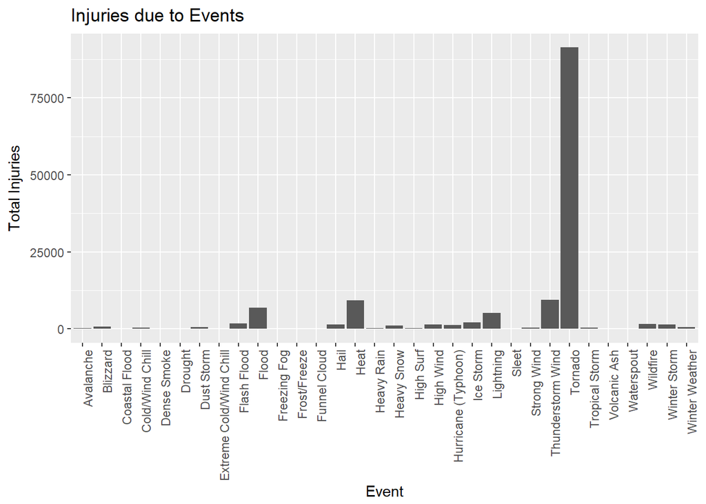

```r
a <- temp %>%
     group_by(EVTYPE_c) %>%
     summarize(totalInjuries = sum(INJURIES))

event <- a[which.max(a$totalInjuries),'EVTYPE_c']


ggplot(data=a, aes(x=EVTYPE_c, y=totalInjuries)) +
    geom_bar(stat="identity") +
    theme(axis.text.x = element_text(angle=90, hjust=1)) +
    xlab('Event') + ylab('Total Injuries') +
    ggtitle('Injuries due to Events')
```

Question 1 Result: As show in the plot, across the United States, Tornado is tne most harmful with respect to population health.

** Question 2 ** Across the United States, which types of events have the greatest economic consequences? In the analysis, I assume the economic consequence is measured by the quantity of property damage.

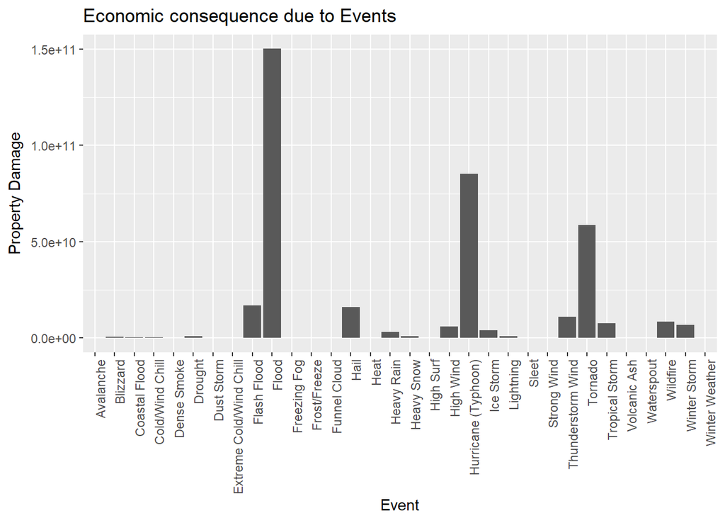

```r
a <- temp %>%
     group_by(EVTYPE_c) %>%
     summarize(totalPropDamage = sum(PROPDamage))

event <- a[which.max(a$totalPropDamage),'EVTYPE_c']

library(ggplot2)

ggplot(data=a, aes(x=EVTYPE_c, y=totalPropDamage)) +
    geom_bar(stat="identity") +
    theme(axis.text.x = element_text(angle=90, hjust=1)) +
    ggtitle('Economic consequence due to Events') +
    xlab('Event') + ylab('Property Damage')
```

Question 2 Result: As show in the plot, across the United States, Flood have the greatest economic consequeces. ```